# Predicting Home Loan Approvals Given An Applicant Financial And Application Details

Author

Reina Cheng, Edmund Yong, Joyce Lin

Published

November 21, 2026

```python
# data handling
import numpy as np
import pandas as pd

# preprocessing
from sklearn.model_selection import train_test_split
from sklearn.pipeline import Pipeline, make_pipeline
from sklearn.compose import ColumnTransformer
from sklearn.impute import SimpleImputer
from sklearn.preprocessing import OneHotEncoder, StandardScaler, FunctionTransformer


# models and cross-validation
from sklearn.dummy import DummyClassifier
from sklearn.linear_model import LogisticRegression
from sklearn.model_selection import StratifiedKFold, cross_validate, cross_val_predict

# evaluation and plots
import matplotlib.pyplot as plt
from sklearn.metrics import (accuracy_score, f1_score, roc_auc_score,
                             classification_report, ConfusionMatrixDisplay,
                             RocCurveDisplay)
```

# Summary

This project investigates whether a logistic regression classification model can predict home loan approval outcomes using applicant and financial features from the [Finance Loan Approval Prediction Data](https://www.kaggle.com/datasets/krishnaraj30/finance-loan-approval-prediction-data/data) available on Kaggle. We evaluated the model against a majority-class baseline using accuracy, F1, and Area Under the Receiver Operating Characteristic Curve (ROC AUC). The logistic regression model outperformed the baseline, achieving a test accuracy of 78.9% accuracy, and ROC AUC of 0.711. However, despite its relatively high overall accuracy, the model only correctly identified 12 of 38 rejected applications; this highlights the importance of evaluating classification models beyond accuracy, particularly when working with imbalanced datasets. Given the dataset’s small size, limited information, and the model’s poor performance in identifying rejections, the results should not be generalized to real-world lending decisions without further tuning and training.

# Introduction

Homeownership is one of the largest and most significant financial commitments many people will make in their lives, and lending institutions must cautiously assess loan applications to determine whether applicants meet their lending criteria. Most applicants do not fully understand the factors influencing loan approval decisions beyond their own financial circumstances, and this analysis strives to provide insights into the home loan approval process.

The project investigates whether a machine learning classification model can accurately predict home loan approval outcomes using applicant and loan characteristics, and then identify the features that drive approval or rejection. We evaluate if a logistic regression model performs better than a majority-class baseline and examine its effectiveness in identifying both approved and rejected applications. Understanding these differences is important because overall accuracy score may not fully reflect a model’s ability to distinguish between the two outcomes for imbalanced datasets.

We trained a logistic regression model to compare its performance against a baseline model that always predicts the majority class. Model performance was evaluated using accuracy, F1 score, and ROC AUC along with a confusion matrix to examine classification errors. This approach allows us to assess whether the model improves upon the baseline as well as whether its predictions are reliable.

# Methods

## Data

The data set used in this project is the “Finance Loan Approval Prediction Data” set, uploaded to Kaggle by user krishnaraj30 and described as home loan approval prediction data. It can be found [here](https://www.kaggle.com/datasets/krishnaraj30/finance-loan-approval-prediction-data). The data is sourced from Kaggle, uploaded by Analytics Vidhya and titled “Loan Prediction” practice problem. It’s based on Dream Housing Finance, a company that offers home loans in urban, semiurban and rural areas and checks each customer’s eligibility after they apply. Each row in the data set represents one loan application, including whether the loan was approved (`Loan_Status`: Y or N) and several applicant and loan characteristics: demographics (gender, marital status, number of dependents, education, self-employment), finances (applicant and co-applicant income, loan amount in thousands, loan term in months), whether the applicant’s credit history meets the lender’s guidelines (`Credit_History`), and the property area (urban, semiurban or rural). Approval decisions were made by the lender.

The dataset contains two files, `train.csv` (614 applications, 13 columns) and `test.csv` (367 applications). `test.csv` was the competition submission file, and its `Loan_Status` labels were withheld for scoring, so it cannot be used to evaluate a model. We therefore use only `train.csv` and split it into our own training (80%) and test (20%) sets, stratified by `Loan_Status`. `test.csv` is loaded but not used in this analysis.

## reading data

```python
# reading data
train = pd.read_csv("../data/raw/train.csv")
test = pd.read_csv("../data/raw/test.csv")
```

# Analysis

## EDA

```python
train.info()
```

```
<class 'pandas.DataFrame'>
RangeIndex: 614 entries, 0 to 613
Data columns (total 13 columns):
 #   Column             Non-Null Count  Dtype
---  ------             --------------  -----
 0   Loan_ID            614 non-null    str
 1   Gender             601 non-null    str
 2   Married            611 non-null    str
 3   Dependents         599 non-null    str
 4   Education          614 non-null    str
 5   Self_Employed      582 non-null    str
 6   ApplicantIncome    614 non-null    int64
 7   CoapplicantIncome  614 non-null    float64
 8   LoanAmount         592 non-null    float64
 9   Loan_Amount_Term   600 non-null    float64
 10  Credit_History     564 non-null    float64
 11  Property_Area      614 non-null    str
 12  Loan_Status        614 non-null    str
dtypes: float64(4), int64(1), str(8)
memory usage: 62.5 KB
```

```python
train.describe()
```

|  | ApplicantIncome | CoapplicantIncome | LoanAmount | Loan_Amount_Term | Credit_History |
| --- | --- | --- | --- | --- | --- |
| count | 614.000000 | 614.000000 | 592.000000 | 600.00000 | 564.000000 |
| mean | 5403.459283 | 1621.245798 | 146.412162 | 342.00000 | 0.842199 |
| std | 6109.041673 | 2926.248369 | 85.587325 | 65.12041 | 0.364878 |
| min | 150.000000 | 0.000000 | 9.000000 | 12.00000 | 0.000000 |
| 25% | 2877.500000 | 0.000000 | 100.000000 | 360.00000 | 1.000000 |
| 50% | 3812.500000 | 1188.500000 | 128.000000 | 360.00000 | 1.000000 |
| 75% | 5795.000000 | 2297.250000 | 168.000000 | 360.00000 | 1.000000 |
| max | 81000.000000 | 41667.000000 | 700.000000 | 480.00000 | 1.000000 |

```python
train.head()
```

|  | Loan_ID | Gender | Married | Dependents | Education | Self_Employed | ApplicantIncome | CoapplicantIncome | LoanAmount | Loan_Amount_Term | Credit_History | Property_Area | Loan_Status |
| --- | --- | --- | --- | --- | --- | --- | --- | --- | --- | --- | --- | --- | --- |
| 0 | LP001002 | Male | No | 0 | Graduate | No | 5849 | 0.0 | NaN | 360.0 | 1.0 | Urban | Y |
| 1 | LP001003 | Male | Yes | 1 | Graduate | No | 4583 | 1508.0 | 128.0 | 360.0 | 1.0 | Rural | N |
| 2 | LP001005 | Male | Yes | 0 | Graduate | Yes | 3000 | 0.0 | 66.0 | 360.0 | 1.0 | Urban | Y |
| 3 | LP001006 | Male | Yes | 0 | Not Graduate | No | 2583 | 2358.0 | 120.0 | 360.0 | 1.0 | Urban | Y |
| 4 | LP001008 | Male | No | 0 | Graduate | No | 6000 | 0.0 | 141.0 | 360.0 | 1.0 | Urban | Y |

```python
train.isna().sum()
```

```
Loan_ID               0
Gender               13
Married               3
Dependents           15
Education             0
Self_Employed        32
ApplicantIncome       0
CoapplicantIncome     0
LoanAmount           22
Loan_Amount_Term     14
Credit_History       50
Property_Area         0
Loan_Status           0
dtype: int64
```

In our EDA, we found that missing values are present in several columns, with the largest number in `Credit_History` (50 of 614 applications). We handled missing values as follows:

- `Credit_History`: missing values were kept as their own category, `Unknown`, instead of being imputed. During exploratory analysis we found that the approval rate of applicants with missing credit history was close to that of applicants with good credit history, and very different from those with bad credit history, so the fact that the value is missing carries information.
- `Self_Employed`, `Loan_Amount_Term` and `Dependents`: imputed with the most frequent value.
- `LoanAmount`: imputed with the median, because its distribution is right skewed.

We also made a few row-wise changes to the data. The `Dependents` value `3+` was recoded as `3` so that the column could be treated as numeric, and `Credit_History` was recoded from 1 and 0 to `Good` and `Bad`. We engineered two new features: total household income (`TotalIncome`, the sum of applicant and co-applicant income) and the ratio of the loan amount to total income (`LoanToIncome`). These steps only use values from the same row and do not learn anything from the data, so applying them to both the training and test sets does not cause data leakage.

## Preprocessing

```python
# split train test
# Split train test
train_df, test_df = train_test_split(
    train, test_size=0.2, stratify=train["Loan_Status"], random_state=123
)
```

```python
# row-wise cleaning and feature engineering
def prepare(df):
    df = df.copy()
    # dependents 3+ becomes 3 (numeric)
    df['Dependents'] = df['Dependents'].replace("3+", "3").astype(float)

    # credit history: keep missingness as its own category
    df["Credit_History"] = (df["Credit_History"]
                              .map({1.0: "Good", 0.0: "Bad"})
                              .fillna("Unknown"))

    # engineered features
    df["TotalIncome"] = df["ApplicantIncome"] + df["CoapplicantIncome"]
    df["LoanToIncome"] = df["LoanAmount"] / df["TotalIncome"].replace(0, np.nan)
    return df

train_p = prepare(train_df)
test_p = prepare(test_df)

train_p.to_csv('../data/processed/train_p.csv', index=False)
test_p.to_csv('../data/processed/test_p.csv', index=False)
```

```python
# features and target
y_train = (train_p["Loan_Status"] == "Y").astype(int)
y_test = (test_p["Loan_Status"] == "Y").astype(int)

skewed_cols = ["ApplicantIncome", "CoapplicantIncome", "TotalIncome",
               "LoanAmount", "LoanToIncome"]
other_num_cols = ["Loan_Amount_Term", "Dependents"]
cat_cols = ["Education", "Self_Employed", "Property_Area", "Credit_History"]

feature_cols = skewed_cols + other_num_cols + cat_cols
X_train = train_p[feature_cols]
X_test = test_p[feature_cols]
```

```python
# Column Transformers (fit on train)
skewed_pipe = make_pipeline(
    SimpleImputer(strategy="median"),
    FunctionTransformer(np.log1p, feature_names_out="one-to-one"),
    StandardScaler(),
)
other_num_pipe = make_pipeline(
    SimpleImputer(strategy="most_frequent"),
    StandardScaler(),
)
cat_pipe = make_pipeline(
    SimpleImputer(strategy="most_frequent"),
    OneHotEncoder(handle_unknown="ignore", drop="if_binary", sparse_output=False),
)

preprocess = ColumnTransformer([
    ("skewed", skewed_pipe, skewed_cols),
    ("num", other_num_pipe, other_num_cols),
    ("cat", cat_pipe, cat_cols),
])
```

```python
# quick sanity check: checking if the encoder works the way it was intended.
X_train_sanity = preprocess.fit_transform(X_train)
print(X_train_sanity.shape)
print(preprocess.get_feature_names_out())
print(np.isnan(X_train_sanity).sum())  # expected result: 0
```

```
(491, 15)
['skewed__ApplicantIncome' 'skewed__CoapplicantIncome'
 'skewed__TotalIncome' 'skewed__LoanAmount' 'skewed__LoanToIncome'
 'num__Loan_Amount_Term' 'num__Dependents' 'cat__Education_Not Graduate'
 'cat__Self_Employed_Yes' 'cat__Property_Area_Rural'
 'cat__Property_Area_Semiurban' 'cat__Property_Area_Urban'
 'cat__Credit_History_Bad' 'cat__Credit_History_Good'
 'cat__Credit_History_Unknown']
0
```

## Model

We used logistic regression to predict whether a loan application is approved. We picked it because it’s simple and the coefficients are easy to explain and is widely used for credit scoring and bank lending prediction (Atodaria & Pentar, 2024; Zhang, 2024). That matters in lending, where a bank needs to be able to explain why someone was rejected. As a baseline, we used a dummy classifier that always predicts the most common class (approved). We compared both models with stratified 5-fold cross-validation on the training set, using accuracy, F1 and ROC AUC. Then we fit the logistic regression on the full training set and scored it once on the test set. The analysis was done in Python (Van Rossum and Drake 2009) using requests (Reitz 2011), zipfile (Van Rossum and Drake 2009), NumPy (Harris et al. 2020), pandas (McKinney 2010), Matplotlib (Hunter 2007) and scikit-learn (Pedregosa et al. 2011).

```python
# baseline and logistic regression models, evaluated with stratified 5-fold CV
cv = StratifiedKFold(n_splits=5, shuffle=True, random_state=123)

dummy = Pipeline([
    ("preprocess", preprocess),
    ("clf", DummyClassifier(strategy="most_frequent")),
])

model = Pipeline([
    ("preprocess", preprocess),
    ("clf", LogisticRegression(max_iter=1000)),
])
```

# Results

Table 1: Mean accuracy, F1 score and ROC AUC across the 5 cross-validation folds for the baseline and logistic regression models.

|  | Accuracy | F1 | ROC AUC |
| --- | --- | --- | --- |
| Baseline (most frequent) | 0.686 | 0.814 | 0.500 |
| Logistic regression | 0.809 | 0.874 | 0.762 |

The baseline gets 0.686 accuracy and 0.814 F1 just by approving everyone, but its ROC AUC is 0.5, so it can’t tell approvals and rejections apart at all (Table 1). Logistic regression improves accuracy to 0.809 and F1 to 0.874. The F1 gain is modest because the baseline’s F1 is already inflated by predicting “approved” every time. The biggest improvement is in ROC AUC, which goes from 0.5 to 0.762.

Table 2: Accuracy, F1 score and ROC AUC of the final logistic regression model on the test set.

|  | Accuracy | F1 | ROC AUC |
| --- | --- | --- | --- |
| Logistic regression (test set) | 0.789 | 0.867 | 0.711 |

On the test set, the model gets 0.789 accuracy, 0.867 F1 and 0.711 ROC AUC (Table 2). These are a bit lower than the CV scores, but close enough that the model doesn’t look overfit. Figure 1 shows two ROC curves, one from CV and one from the test set. The test curve is more jagged because it’s based on only 123 applicants (38 rejections), so each applicant moves the curve by a bigger step. For the same reason, the test AUC is less precise than the CV AUC.

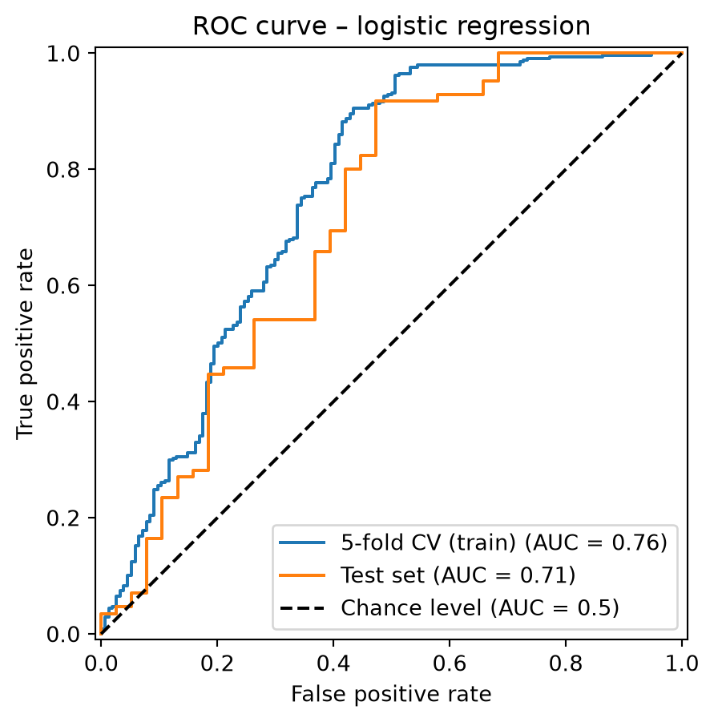

Figure 1: ROC curves for the logistic regression model from 5-fold cross-validation (training set) and from the test set. The dashed line is random guessing (AUC = 0.5).

The confusion matrix (Figure 2) shows the model’s main weakness. It approved all 85 applicants who were actually approved, but it only caught 12 of the 38 rejections. The other 26 were approved when they should have been rejected. So the model leans heavily towards approval, and recall for rejections is only 0.32. For a lender, these two mistakes don’t cost the same. Rejecting a good applicant means losing a customer. Approving a bad applicant can mean a loan that doesn’t get paid back, which is usually much more expensive. Almost all of our model’s mistakes are the expensive kind, so it shouldn’t be making lending decisions on its own.

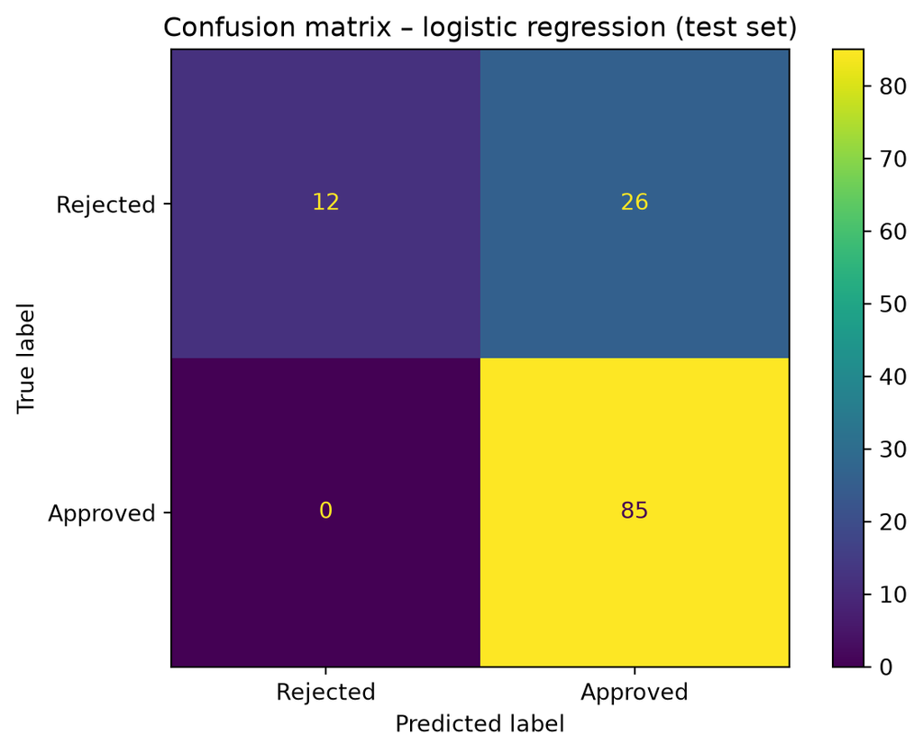

Figure 2: Confusion matrix for the logistic regression model on the test set. Rows are the true loan status and columns are the predicted status.

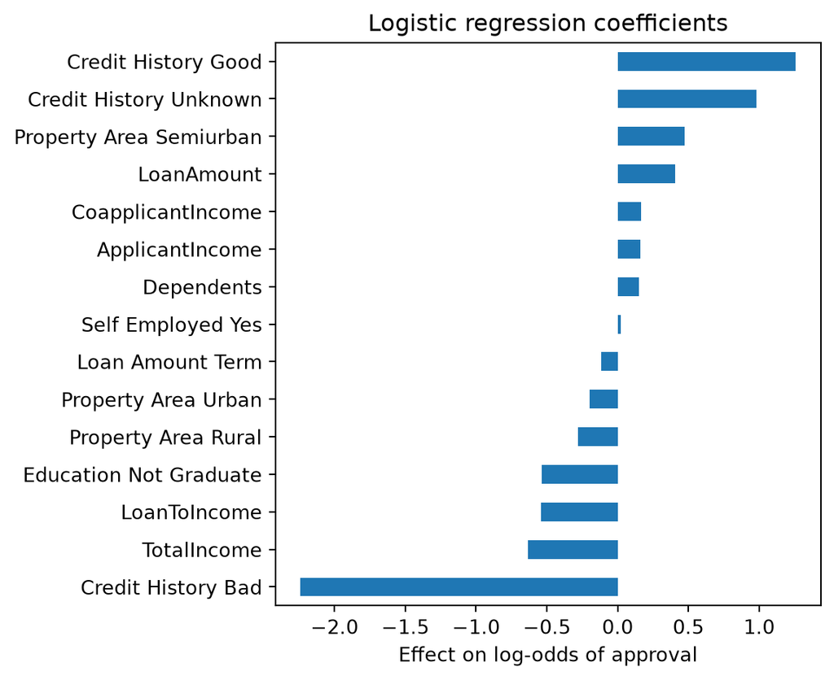

Figure 3: Coefficients of the final logistic regression model. Positive values push towards approval and negative values push towards rejection.

# Discussion

Based on the results of the data analysis, the trained model beats the baseline, but because it approves too many applicants who should be rejected, it isn’t ready for real lending use. There are a few things we could try next. We could raise the decision threshold above the default 0.5, or set `class_weight="balanced"`, so the model rejects more often. This would cut down risky approvals, at the cost of turning away some good applicants. We could also tune the regularization strength `C`, which we left at its default. Finally, we could try models like random forest or gradient boosting, which can pick up interactions between features that logistic regression misses (Udbhav et al., 2022).

There are also some limitations to keep in mind. The data set is small with 614 applications, and we don’t know much about where it comes from, such as which lender, which country or which years. Lending rules and applicants vary a lot between lenders and over time, so the model may not work as well on other data. Our test results come from a single 80/20 split with only 123 applicants with 38 rejections, so they’re uncertain, and a different split could give somewhat different numbers. Lastly, even though we dropped gender and marital status, other features like income or property area could still be correlated with them. Anyone using a model like this would need to check that it treats different groups fairly.

With more training data and additional research time, further studies could delve deeper into the data and look into customer segmentation, which involves splitting customers into groups based on similar traits (Business Development Bank of Canada, 2025), to determine which segments have the highest approval ratings. Another potential path for future research could be to gather larger, more detailed datasets with additional features such as interest rate, current assets, and current debt to determine whether they can further improve the model’s performance.

# References

Krishnaraj30. (2023). *Finance loan approval prediction data* [Data set]. Kaggle. https://www.kaggle.com/datasets/krishnaraj30/finance-loan-approval-prediction-data/data

Atodaria, Zankhana & Pentar, Shubhangi. (2024). Credit Risk Analysis Using Logistic Regression Modeling.. 57.

Zhang, Zehao. (2024). An Application of Logistic Regression in Bank Lending Prediction: A Machine Learning Perspective. Highlights in Business, Economics and Management. 45. 342-347. 10.54097/20qcm204.

BDC. (2025, March 7). What is customer segmentation?. Business Development Bank of Canada (BDC). https://www.bdc.ca/en/articles-tools/entrepreneur-toolkit/templates-business-guides/glossary/segmentation

Udbhav, M., Kumar, R., Kumar, N., Kumar, R., Vijarania, Dr. M., & Gupta, S. (2022). Prediction of Home Loan Status Eligibility Using Machine Learning. https://doi.org/10.2139/ssrn.4121038